# Part 3 - ASA Short Course Second-generation p-values (Full-Day)

# Introduction

- Jeffrey D. Blume, PhD
  - School of Data Science, University of Virginia
- Megan H. Murray, PhD
  - Department of Biostatistics, Vanderbilt University

Resources:

- GitHub with Slides and Code: www.github.com/murraymegan/SGPV-ASA-Short-Course-2022
- RStudio Desktop: www.rstudio.com/products/rstudio/download
- Interrupt or use Zoom chat for questions!
- For technical difficulties email Megan: megan.c.hollister@vanderbilt.edu

# 1 Part 3

## 1.1 Part 3a

### 1.1.1 ProSGPV Simulation

```r
set.seed(1)
sim.data <- gen.sim.data(n = 50, p = 10, s = 4,
                         family = "gaussian",
                         beta.min = 1, beta.max = 5,
                         rho = 0.2, nu = 2)
x <- sim.data[[1]]
y <- sim.data[[2]]
(true.index <- sim.data[[3]])
```

```
## [1] 2 4 5 7
```

```r
true.beta <- sim.data[[4]]
```

- By default, the two-stage algorithm is used in ProSGPV.
- `pro.sgpv` function takes inputs of explanatory variables x, outcome y, outcome type family (default is “gaussian”), stage indicator (default is 2), and a GVIF indicator (default is FALSE).
- A print method is available to show labels of the variables selected by ProSGPV.

```r
sgpv.out.2 <- pro.sgpv(x,y)
sgpv.out.2
```

```
## Selected variables are V2 V5 V7
```

```r
# true.beta
true.index
```

```
## [1] 2 4 5 7
```

- Visualization of variable selection process

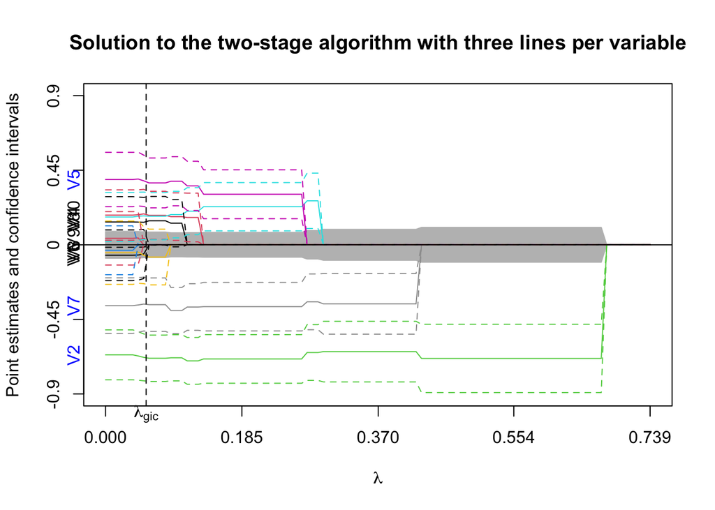

```r
plot(sgpv.out.2)
```

Model Summary

```r
summary(sgpv.out.2)
```

```
##
## Call:
## lm(formula = Response ~ ., data = data.d)
##
## Residuals:
##      Min       1Q   Median       3Q      Max
## -13.0068  -2.3711   0.6028   2.7228  10.3547
##
## Coefficients:
##             Estimate Std. Error t value Pr(>|t|)
## (Intercept) -0.08957    0.71297  -0.126 0.900574
## V2          -5.44915    0.64621  -8.433 6.87e-11 ***
## V5           3.26839    0.80015   4.085 0.000175 ***
## V7          -3.68785    0.77444  -4.762 1.94e-05 ***
## ---
## Signif. codes:  0 '***' 0.001 '**' 0.01 '*' 0.05 '.' 0.1 ' ' 1
##
## Residual standard error: 4.895 on 46 degrees of freedom
## Multiple R-squared:  0.7034, Adjusted R-squared:  0.684
## F-statistic: 36.36 on 3 and 46 DF,  p-value: 3.382e-12
```

- `coef` function can be used to extract the coefficient estimates of length p. When signals are sparse, some of estimates are zero. A comparison shows that the estimates are close to the true effect sizes in the simulation.

```r
beta.hat = coef(sgpv.out.2)
rbind(beta.hat, true.beta)
```

```
##           [,1]      [,2] [,3] [,4]     [,5] [,6]      [,7] [,8] [,9] [,10]
## beta.hat     0 -5.449154    0    0 3.268389    0 -3.687846    0    0     0
## true.beta    0 -5.000000    0    1 2.333333    0 -3.666667    0    0     0
```

- `predict` function can be used to predict outcomes using the selected model.
- In-sample prediction can be made by calling `predict(sgpv.out.2)` and out-of-sample prediction can be made by feeding new data set into the newdata argument.

```r
preds = predict(sgpv.out.2)

cbind(preds, y)
```

```
##          preds           y
## 1    8.2993645  14.9532559
## 2   -8.8659786 -14.1402243
## 3    8.1576658   5.6770472
## 4   16.7141593  21.2556549
## 5   -6.8915154 -11.9104536
## 6    6.0995442  -6.9072594
## 7   -3.3938972  -6.4016210
## 8    2.6410697  -2.2790190
## 9   -7.8186176  -6.5374117
## 10   4.8723877   3.9731037
## 11 -10.7865487  -9.6668518
## 12   0.6084523  -1.4338933
## 13   3.8841387   5.2537291
## 14  -3.8550714  -2.9899402
```

[output cut: 36 more lines]

In addition to the two-stage algorithm, one-stage algorithm can also be used to select variables when n > p. The computation time is shorter for the one-stage algorithm at the expense of slightly reduced support recovery rate in the limit.

```r
sgpv.out.1 <- pro.sgpv(x,y,stage=1)
sgpv.out.1
```

```
## Selected variables are V2 V5 V7
```

The one-stage algorithm missed V4 and only selected three variables. What happened?

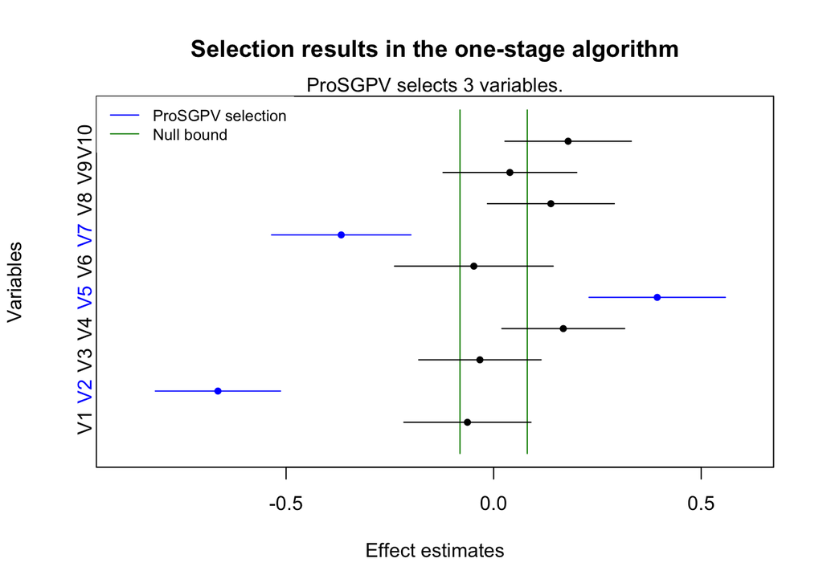

```r
plot(sgpv.out.1)
```

### 1.1.2 ProSGPV Real Life Example

We can load the Tehran Housing data `t.housing` stored in the package.

A dataset containing Tehran housing data. The data set has 372 observations. There are 26 explanatory variables at baseline, including 7 project physical and financial features (V2-V8) and 19 economic variables and indices (V11-V29). The outcome (V9) is the sales price of a real estate single-family residential apartment.

```r
set.seed(999)

# prepare the data
x = t.housing[,-ncol(t.housing)]
y = t.housing$V9

# run ProSGPV
out.sgpv.2 <- pro.sgpv(x = x, y = y)
```

The two-stage algorithm selects the following variables.

```r
out.sgpv.2
```

```
## Selected variables are V8 V12 V13 V15 V17 V26
```

- V9: Actual sales price (outcome)
- V8: Price of the unit at the beginning of the project per square meter
- V12: Building services index for preselected base year
- V13: Wholesale price index of building materials for the base year
- V15: Cumulative liquidity
- V17: Land price index for the base year
- V26: CPI of housing, water, fuel & power in the base year

We can view the summary of the final model.

```r
summary(out.sgpv.2)
```

```
##
## Call:
## lm(formula = Response ~ ., data = data.d)
##
## Residuals:
##      Min       1Q   Median       3Q      Max
## -1276.35   -75.59    -9.58    59.46  1426.22
##
## Coefficients:
##               Estimate Std. Error t value Pr(>|t|)
## (Intercept)  1.708e+02  3.471e+01   4.920 1.31e-06 ***
## V8           1.211e+00  1.326e-02  91.277  < 2e-16 ***
## V12         -2.737e+01  2.470e+00 -11.079  < 2e-16 ***
## V13          2.185e+01  2.105e+00  10.381  < 2e-16 ***
## V15          2.041e-03  1.484e-04  13.756  < 2e-16 ***
## V17         -3.459e+00  8.795e-01  -3.934  0.00010 ***
## V26         -4.683e+00  1.780e+00  -2.630  0.00889 **
## ---
## Signif. codes:  0 '***' 0.001 '**' 0.01 '*' 0.05 '.' 0.1 ' ' 1
##
## Residual standard error: 194.8 on 365 degrees of freedom
## Multiple R-squared:  0.9743, Adjusted R-squared:  0.9739
## F-statistic:  2310 on 6 and 365 DF,  p-value: < 2.2e-16
```

Coefficient estimates can be extracted by use of coef.

```r
coef(out.sgpv.2)
```

```
##  [1]   0.000000000   0.000000000   0.000000000   0.000000000   0.000000000
##  [6]   0.000000000   1.210755031   0.000000000 -27.367601037  21.853920174
## [11]   0.000000000   0.002040784   0.000000000  -3.459496972   0.000000000
## [16]   0.000000000   0.000000000   0.000000000   0.000000000   0.000000000
## [21]   0.000000000   0.000000000  -4.683172725   0.000000000   0.000000000
## [26]   0.000000000
```

In-sample prediction can be made using S3 method predict and an external sample can be provided to make out-of-sample prediction with an argument of newx in the predict function.

```r
head(predict(out.sgpv.2))
```

```
##         1         2         3         4         5         6
## 1565.7505 3573.7793  741.7576  212.1297 5966.1682 5724.0172
```

S3 method plot can be used to visualize the variable selection process.

First, we plot the full solution path with point estimates and 95% confidence intervals. Note that the null region is in grey. The selected variables are colored blue on the y-axis. `lambda.max` controls the limit of the X-axis.

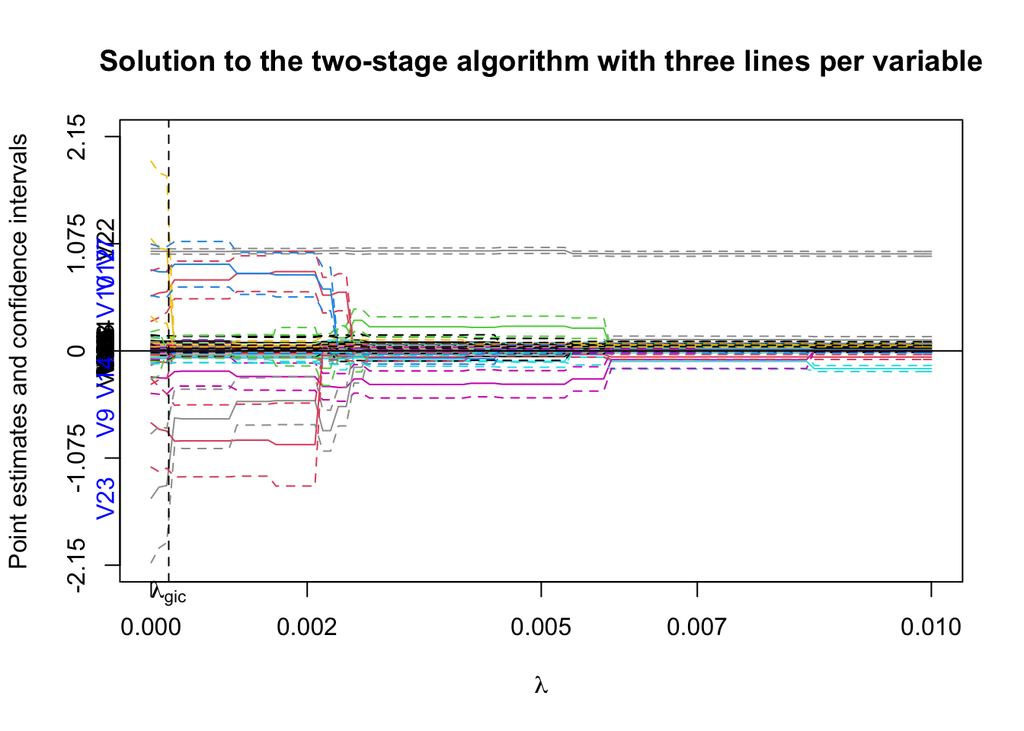

```r
plot(out.sgpv.2, lambda.max = 0.01)
```

Alternatively, we can plot the confidence bound that is closer to the null.

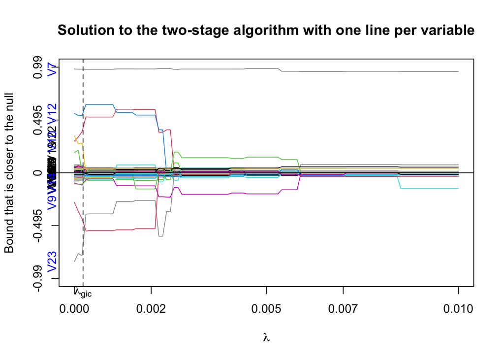

```r
plot(out.sgpv.2,lpv=1,lambda.max=0.01)
```

## 1.2 Part 3b

### Vignettes

- [Linear ProSGPV](https://cran.r-project.org/web/packages/ProSGPV/vignettes/linear-vignette.html)
- [GLM and Cox ProSGPV](https://cran.r-project.org/web/packages/ProSGPV/vignettes/glm-cox-vignette.html)